# Pemrograman dalam Sains

Sebuah Catatan Kuliah

Ikang Fadhli

20921004@mahasiswa.itb.ac.id

24 August 2021

# 1 SILABUS

## 1.1 Keterangan Umum

### 1.1.1 Silabus Ringkas

Kuliah ini dirancang untuk memberikan pemahaman dasar-dasar bahasa pemrograman kepada mahasiswa, khususnya mahasiswa yang tidak memiliki dasar pemrograman.

### 1.1.2 Silabus Lengkap

Kuliah ini dirancang untuk memberikan pemahaman dasar-dasar bahasa pemrograman kepada mahasiswa, khususnya mahasiswa yang tidak memiliki dasar pemrograman. Bahasa pemrograman yang akan digunakan dalam kuliah ini adalah bahasa pemrograman Python. Selain dasar-dasar bahasa pemrograman python, kuliah ini juga akan mengaplikasikan bahasa pemrograman Python untuk memodelkan suatu sistem dalam memecahkan permasalahan di bidang sains.

### 1.1.3 *Outcomes*

1. Mahasiswa mampu memahami dan menguasai bahasa pemrograman Python.
2. Mahasiswa mampu mengaplikasikan bahasa pemrograman Python untuk membuat model suatu sistem dalam memecahkan permasalahan di bidang sains.

### 1.1.4 Panduan Penilaian

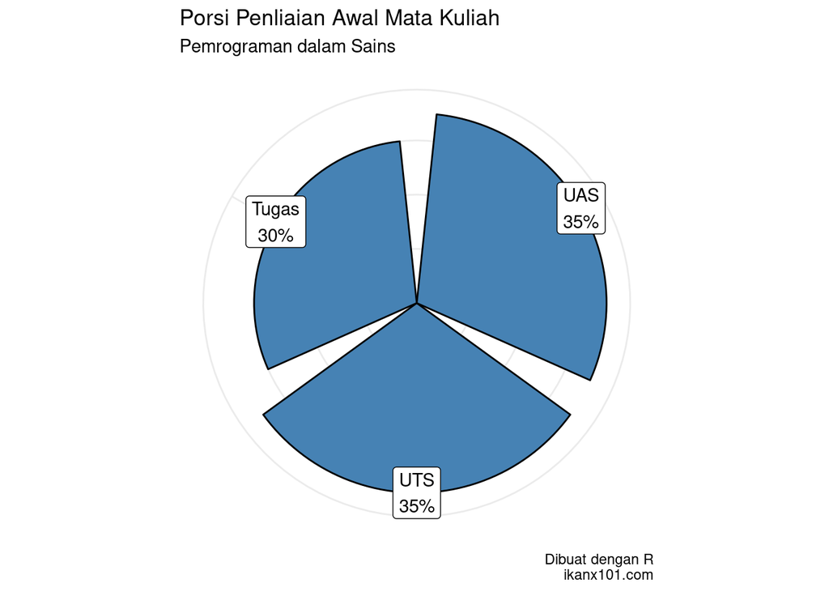

```r
data.frame(
  ket = c("UTS","UAS","Tugas"),
  persen = c(35,35,30)
) %>%
  mutate(label = paste0(ket,"\n",persen,"%")) %>%
  ggplot(aes(x = reorder(ket,-persen),
             y = persen)) +
  geom_col(fill = "steelblue",
           color = "black") +
  geom_label(aes(label = label)) +
  labs(title = "Porsi Penliaian Awal Mata Kuliah",
       subtitle = "Pemrograman dalam Sains",
       caption = "Dibuat dengan R\nikanx101.com") +
  theme_minimal() +
  theme(axis.title = element_blank(),
        axis.text = element_blank()) +
  coord_polar()
```

## 1.2 Satuan Acara Perkuliahan

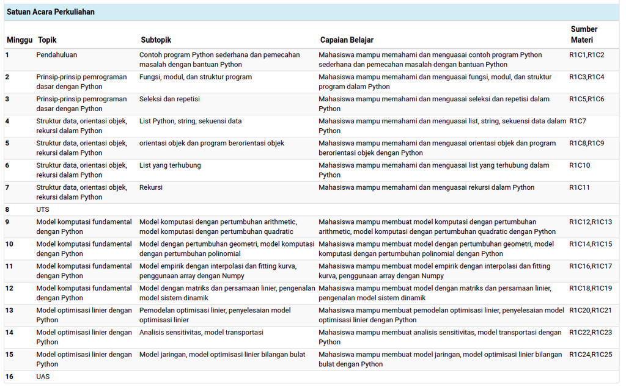

```r
knitr::include_graphics("Screenshot from 2021-08-24 13-28-36.png")
```

## 1.3 Info Lainnya

Tiga tahun lalu belum ada kuliah ini. Kemudian muncul masalah bahwa mahasiswa S2 tidak memiliki kemampuan algoritma.

## 1.4 Buku

[figure not shown]

```r
knitr::include_graphics("Screenshot from 2021-08-24 14-19-09.png")
```

[figure not shown]

```r
knitr::include_graphics("Screenshot from 2021-08-24 14-20-12.png")
```

## 1.5 Tugas dan Koding

**RBL** (*Research Based Learning*): Mini *Project Research* yang dilakukan secara berkelompok, per kelompok mahasiswa terdiri atas 2 orang anggota. Nilai **RBL** menggantikan salah satu nilai Ujian (UTS atau UAS) yang nilanya paling kecil.

# 2 PERTEMUAN MINGGU I

[figure not shown]

Presensi 24 Agustus 2021

```r
knitr::include_graphics("MicrosoftTeams-image.png")
```

## 2.1 *Slides* Penting

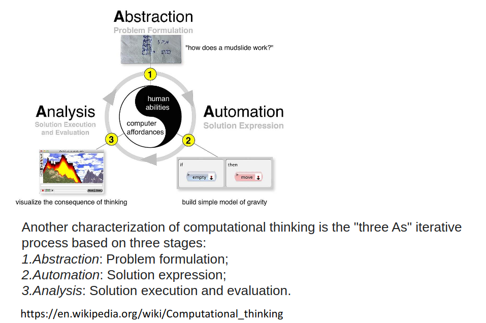

```r
knitr::include_graphics("Screenshot from 2021-08-24 14-28-33.png")
```

[figure not shown]

```r
knitr::include_graphics("Screenshot from 2021-08-24 14-30-18.png")
```

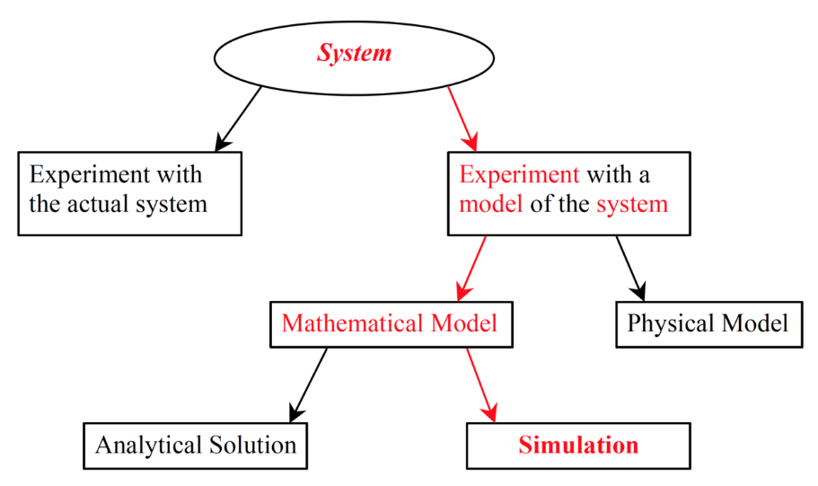

```r
knitr::include_graphics("Screenshot from 2021-08-24 14-34-20.png")
```

*Mathematical model* bisa jadi masih gak berbentuk atau belum terjadi sedangkan *physical model* sudah pasti ada.